# Initiation Git & Github

# I/. Présentation

## 1. Intérêts

La sauvegarde sécurisée des scripts d’un projet dans un dépôt distant (Github)

La facilitation du travail en équipe grâce au stockage dans un historique de l’ensemble des étapes de développement d’un projet

La popularité de cet outil de versionning reconnu dans le monde avec une communauté de 94 millions de développeurs sur Github dont 20 millions de nouveaux utilisateurs en 2022

L’utilisation de Github comme une vitrine de ses compétences sur le marché du travail

La participation à des projets publics pour participer au développement global des scripts communautaires et développer dans le même temps ses compétences et son réseau

## 2. Définitions

Git est un gestionnaire de versions utilisé pour créer et gérer un dépôt local

Un dépôt local est un entrepôt virtuel permettant le stockage des scripts d’un projet sur sa machine

Github est un service en ligne utilisé pour héberger un projet sur un dépôt distant

Un dépôt distant correspond donc à la version dématérialisée d’un dépôt local

## 3. Workflow

### 3.1 Développement des projets

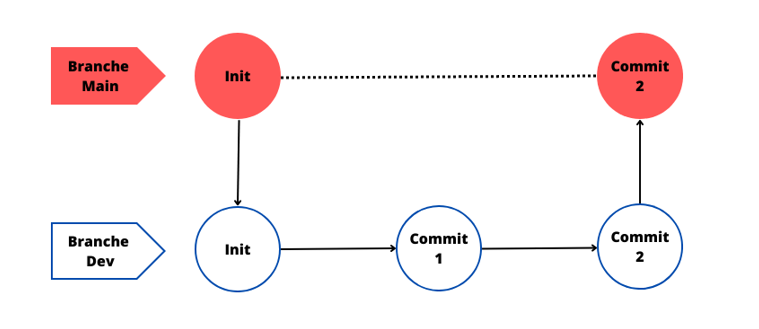

### 3.2 Lien entre Git et Github

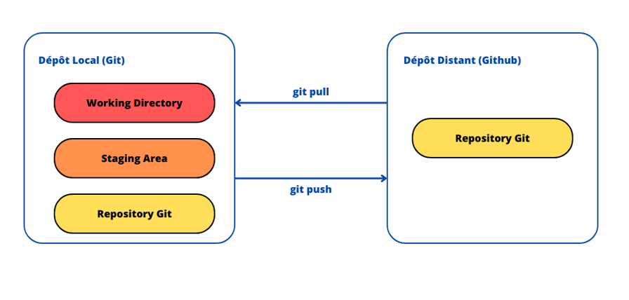

## 4. Concepts clés

Branch : Tout répertoire Git doit posséder une branche main. Il s’agit de votre branche de production. Le développement du projet ne s’effectue pas sur cette branche. Il est nécessaire de créer une branche dev à partir de la branche main pour le développement de vos scripts. Vous pouvez naturellement nommer cette ou ces branches de développement comme vous le souhaitez.

Pull : En local, un *pull* permet de récupérer des modifications issues de l’image d’une branche du dépôt distant sur Github. Autrement dit, en local, un *pull* permet de récupérer les modifications réalisées par vos collaborateurs sur une branche de votre projet. Sur Github, *i.e.* sur le dépôt distant, une pull request permet de fusionner une branche de développement vers une autre branche. Par exemple, à la fin d’une des étapes du projet, on réalise une *pull request* de la branche *dev* vers la branche *main*.

Add : Lorsque des modifications sont effectuées sur une branche d’un projet Git, elles le sont dans ce qu’on appelle le Working directory. Pour que ces modifications soient enregistrées dans votre répertoire Git, il est nécessaire de les ajouter avec la commande *git add*, envoyant ainsi les modifications dans la zone Staging area.

Stage : Après avoir *add* vos modifications, elles sont *staged*. Autrement dit, après avoir ajouté vos modifications, elles sont en attente d’être empaquetées dans un commit. Cette zone de transit est nommée staging area.

Commit : Lorsque des modifications sont dans la Staging area vous pouvez alors les empaquetées dans un *commit*. Ce *commit* représente l’image de votre projet à cet instant donné. Au besoin, il est possible de revenir à n’importe quel commit antérieur. L’ensemble de ces *commits* constituent l’historique de votre projet. Une modification doit nécessairement être ajoutée puis empaquetée dans un *commit* pour exister dans l’historique d’un projet. De ce fait, cette modification sera maintenant dans la zone Repository Git du dépôt local.

Push : La création du commit permet d’enregistrer les modifications effectuées dans votre Repository Git en local. Vous allez ensuite pouvoir pousser votre commit sur votre branche de développement dans le Repository Git de votre dépôt distant sur Github avec un *push*. Autrement dit, vous allez mettre à disposition de vos partenaires vos avancées sur le projet. Ainsi, ils pourront récupérer vos modifications sur leur dépôts local en réalisant un *pull* sur la branche cible, i.e. une mise à jour de cette branche.

⚠ Remarque : La dénomination conventionnelle de la branche de production d’un projet Git est devenue main depuis 2020. Il est donc possible de rencontrer sur des projets plus anciens une branche de production nommée master.

## 5. Installation de Git

Git est disponible en téléchargement à l’adresse suivante : https://git-scm.com/downloads

[figure not shown]

Sous Mac et Linux, l’utilisation de Git s’effectue directement à partir du terminal.  
Sous Windows, il est nécessaire d’utiliser Git Bash.

Lors de l’installation de Git pour Windows, il faut donc bien penser à sélectionner Git Bash en cliquant sur *“Windows Explorer Integration”* comme indiqué dans la capture ci-dessous. Sinon, la sélection par défaut des autres paramètres est suffisante.

[figure not shown]

## 6. Création d’un compte Github

Github est accessible à l’adresse suivante : https://github.com

[figure not shown]

La création de votre compte Github est réalisable en cliquant sur *“Sign Up”*.

⚠ Remarque : Votre profil Github peut devenir un portfolio de vos projets. Il peut donc être intéressant d’utiliser votre adresse mail personnelle et non celle de votre université ou de votre entreprise.

Dans le cas d’une utilisation de Github avec un Mac, il est nécessaire de créer un token qui vous permettra de vous connecter à Github depuis le terminal du Mac. Pour créer ce token, il faut réaliser les étapes suivantes directement sur Github :

1. Aller sur GitHub et s’identifier
2. En haut à droite, cliquer sur votre profil pour afficher le menu déroulant
3. Puis cliquer sur Settings et sur Developper settings
4. Ensuite, cliquer sur Personnal acces tokens et sélectionner Tokens (classic)
5. Entrer une courte description de l’utilisation de votre token
6. Choisir la durée de vie du token, i.e. la date d’expiration après laquelle un nouveau token devra être généré pour lier Github à votre machine
7. Sélectionner ensuite les champs d’utilisation du token comme : repo, write:packages, etc.

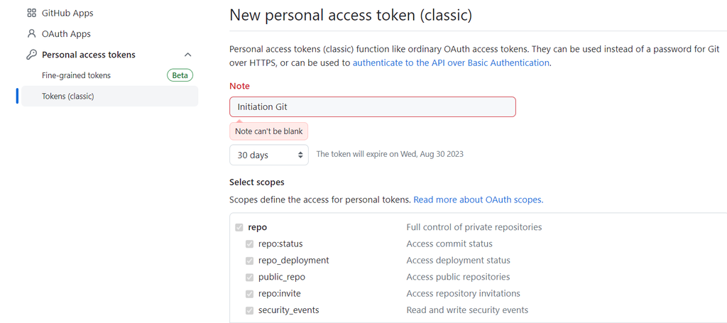

8. Puis cliquer sur Generate token

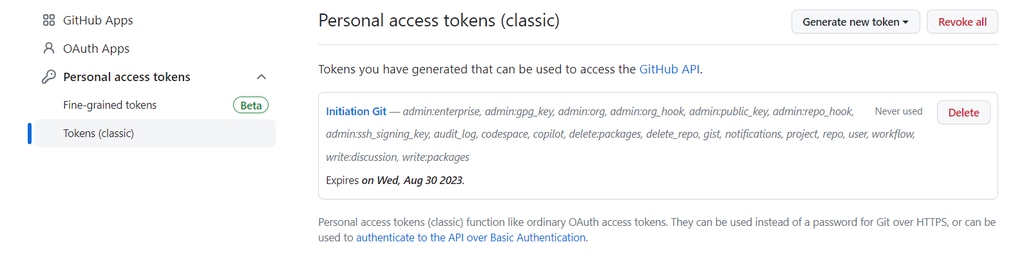

9. Cliquer sur votre token pour accéder ensuite à la clé qui vous servira de mot de passe pour se connecter à Github depuis le terminal du Mac

⚠ Remarque : Pour se connecter à Github depuis le terminal d’un Mac, le mot de passe correspond donc au token décrit précédemment et l’identifiant correspond à l’adresse email ou l’identifiant de votre compte Github.

# II/. Routines git

## 1. Initialisation de git

Après l’installation de Git sur sa machine, il est nécessaire de l’initialiser en paramétrant certaines options. Les lignes de commande ci-dessous permettent de personaliser votre Git. Ces commandes ne sont à réaliser qu’une seule fois.

cd Document  
mkdir Projet  
cd Projet  
git init  
git config -l  
git config --global user.name “Léo Dutertre-Ladurée”  
git config --global user.email “ldutertreladuree@gmail.com”  
git config --global color.diff auto  
git config --global color.status auto  
git config --global color.branch auto  
git config --global core.editor auto  
git config --global merge.tool vimdiff  
git config -l

# Se placer dans le dossier Document  
# Créer le dossier Projet  
# Se placer dans le dossier Projet  
# Initialisation git du dossier Init  
# Afficher la configuration globale de git  
# Configurer votre nom  
# Configurer votre adresse mail  
# Configurer les couleurs  
# Configurer l’éditeur  
# Vérifier les modifications

⚠ Remarque : Il est nécessaire de renseigner la même adresse mail que celle utilisée lors de la création de votre compte Github.

## 2. Création d’un dépôt distant Github

Pour créer un nouveau dépôt distant sur Github vous pouvez :

Aller sur votre profil Github

Aller ensuite dans l’onglet *“Repositories”*

Puis vous pouvez cliquer sur *“New”* en haut à droite

[figure not shown]

[figure not shown]

## 3. Cloner un dépôt distant Github

Après avoir créé le dépôt distant sous Github, vous pouvez le cloner sur votre machine pour obtenir le dépôt local. Autrement dit, vous récupérez en local l’image de votre projet créé sur Github.  
Pour cloner votre projet sur votre machine vous devez :

- Cliquer sur *“Code”* en haut à droite
- Puis copier l’adresse HTTPS de votre projet

[figure not shown]

Ensuite, ouvrir Git Bash (ou le terminal sous Mac et Linux) et saisir les commandes ci-dessous avec l’adresse HTTPS de votre projet :

cd Document  
git clone https://github.com/LeoDtrt/NewProject.git  
cd NewProject  
git remote -v  
git status

# Se placer dans le dossier Document  
# Cloner le nouveau projet en local  
# Se placer dans le nouveau projet  
# Vérifier de l’adresse et le statut *origin*  
# Checker l’état de votre répertoire Git

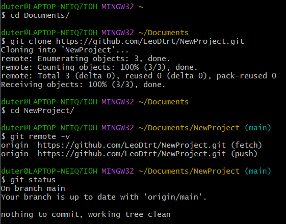

- git remote : Permet de vérifier votre statut origin. Il est possible également d’ajouter d’autres remotes, *i.e.* d’autres liens vers des versions différentes d’un même projet. Autrement dit, si une personne à créé un fork (une copie de votre projet sur Github), vous pouvez ajouter un lien vers son projet en récupérant son adresse HTTPS.
- git status : Cette commande est votre nouvelle meilleure amie. Elle va vous permettre à chaque instant de savoir quelles modifications vous avez effectué (ajouts, modifications et suppressions). Plus précisément, vous allez enregistrer des modifications tout au long de votre développement via des checkpoints que l’on nomme commit. La commande *git status* permet donc de connaitre toutes les modifications effectuées depuis le dernier commit.

⚠ Remarque : La capture d’écran ci-dessus montre que vous êtes placé sur la branche main. Vous pouvez le voir avec la commande *git status* et également entre parenthèses à la fin de votre emplacement dans les répertoires si vous êtes placé dans votre dépôt local Git. ⚠ Ne pas coder sur la branche main ⚠.

## 4. Gestion des branches

La bonne pratique est de ne pas développer un projet sur la branche de production d’un projet, autrement dit sur la branche *main*. L’idée est donc de créer une branche à partir du *main*, *i.e.* créer une copie de la branche de production pour développer une étape du projet. Une fois le développement de cette étape terminé, vous pouvez *merge* votre branche *dev* à la branche *main*.

cd NewProject  
git remote update  
git branch -a  
git branch dev  
git branch -a  
git checkout dev  
git branch -a  
git checkout main  
git branch -d dev  
git branch -D dev

# Se placer dans le répertoire Git NewProject  
# Récupérer l’accès à d’éventuelles nouvelles branches  
# Afficher l’ensemble des branches liées au projet  
# Créer la branche dev à partir de l’image de la branche main  
# Vérifier la création de la branche dev  
# Se placer sur la branche dev  
# Vérifier si l’étoile est bien à côté de la branche dev  
# Se replacer sur la branche main pour supprimer dev  
# Supprimer la branche dev  
# Forcer la suppression de la branche dev (si vous êtes sûr)

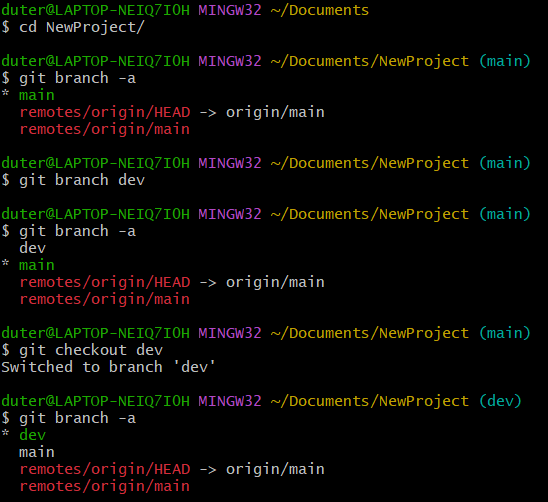

⚠ Remarque : Lors de la création d’une branche, vous réalisez une copie de la branche sur laquelle vous êtes placé. Il est donc nécessaire de ⚠ savoir sur quelle branche vous êtes situé ⚠.

## 5. Ajout et récupération des modifications

Après avoir effectué des modifications sur la branche de développement (*dev*), à tout moment il est possible d’ajouter ses modifications et de les enregistrer dans le répertoire Git du projet via un commit.

La création du *commit* sur la branche *dev* constitue une sauvegarde dans le Repository Git du dépôt local. Il faut ensuite pousser cette sauvegarde dans le Repository Git du dépôt distant sur Github via un *push*.

Enfin, vous pouvez récupérer, si elles existent, les modifications de vos partenaires sur cette branche avec un *pull*. Si vous souhaitez récupérer les modifications réalisées par un partenaire sur une autre branche, il suffit de déclarer le nom de cette branche dans le *pull*.

git status  
git add README.md  
git add .  
git status  
git commit -m “Première Modification”  
git status  
git reset HEAD~1  
git push origin dev  
git pull origin dev

# Vérifier l’état des modifications de la branche dev  
# Ajouter le fichier README.md  
# Ajouter toutes les modifications visibles avec git status  
# Les modifications ajoutées ont le statut staged  
# Créer le commit de ces modifications  
# “Nothing to commit”, les modifications sont sauvergardées  
# Suppression du dernier commit en cas d’erreur  
# Le commit est poussé sur la branche dev sur Github  
# Récupération des modifications présentes sur Github

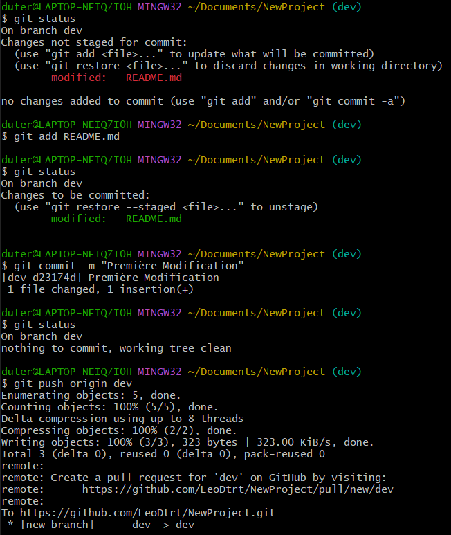

Quelques commandes utiles :

git log –oneline  
git log –oneline –graph  
git restore README.md  
git restore .

# Affichage des commits réalisés  
# Affichage du graphique des branches du projet  
# Suppression des modifications sur le fichier README.md  
# Suppression des modifications sur tous les fichiers modifiés

⚠ Remarque : La commande git restore ne supprime pas réellement les modifications d’un fichier. Cette commande permet de redonner l’image que le fichier avait lors du dernier commit. Ceci implique que cette commande ne permettra pas de supprimer les modifications d’un fichier qui n’aurait pas fait l’objet d’un commit, i.e. les fichiers avec un statut untracked.

## 6. Merge sur la branche *main*

Il y a deux possibilités pour *merge* une branche *dev* avec la branche *main* :

1. En local suivi d’une livraison du *main* sur le dépôt distant sur Github.
2. En ligne sur Github en poussant d’abord ses modifications sur sa branche *dev* sur le dépôt distant puis en faisant une *pull request* de votre la branche *dev* vers la branche *main*.

### 6.1 Merge en local

git status  
git add .  
git commit -m “Nouvelle Modification”  
git checkout main  
git merge dev  
git status  
git push origin main

# Vérifier l’état des modifications de la branche dev  
# Ajouter le fichier README.md  
# Créer le commit de ces modifications  
# Se placer sur la branche main  
# Fusion de la branche dev vers la branche main  
# La branche main est en avance d’un commit en local  
# Alors on pousse le commit d’avance en local sur Github

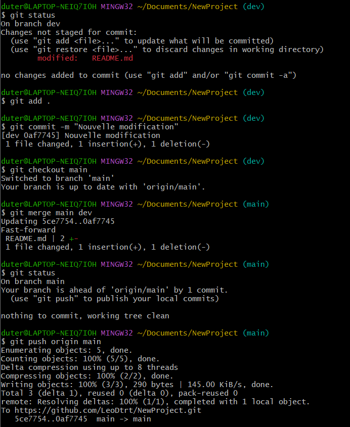

Un message s’affiche sur Github indiquant le fait que la branche *main* du projet n’est pas protégée. Autrement dit, toutes les personnes travaillant sur le projet peuvent développer sur la branche *main* et pousser leurs modifications sans restriction. La branche main doit être protégée car c’est votre branche de production.

[figure not shown]

Le problème étant, il faut un compte Team ou Entreprise qui sont payant pour pouvoir protéger une branche. Il est donc fortement recommandé d’alimenter la branche *main* via une pull request de la branche *dev* vers la branche *main* directement sur Github.

### 6.2 Pull request sur Github

- Ajout des modifications sur la branche *dev*
- Commit de ces modifications sur la branche *dev* en local
- Push de ce commit sur la branche *dev* en ligne sur Github

git status  
git add .  
git commit -m “Nouvelle Modification”  
git push origin dev

# Vérifier l’état des modifications de la branche dev  
# Ajouter toutes les modifications visibles avec git status  
# Créer le commit de ces modifications  
# Le commit est poussé sur la branche dev sur Github

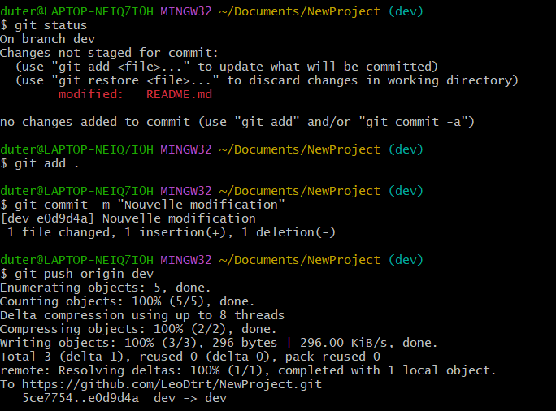

- Cliquer sur l’onglet Pull requests sur la page du projet sur Github
- Puis cliquer sur New pull request en vert en haut à droite
- Ensuite sélectionner base:main et compare:dev, *i.e.* une *pull request* de la branche *dev* vers la branche *main*
- Et cliquer sur Create pull request en vert en haut à droite

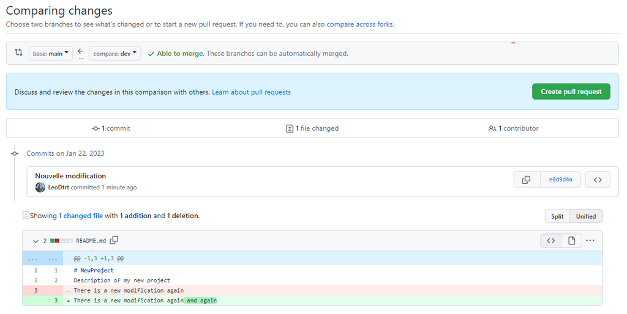

- S’il n’y a pas de conflits, cliquer sur Merge pull request

[figure not shown]

- Puis cliquer sur Confirm merge

[figure not shown]

- La pull request de la branche *dev* vers la branche *main* est terminée
- Il est possible de supprimer la branche *dev* sur Github, *i.e* sur le dépôt distant
- Il faut ensuite récupérer les modifications de la branche *main* sur le dépôt local :

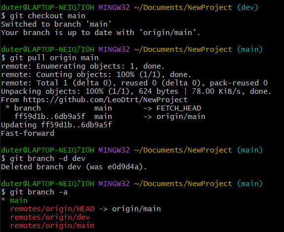

git checkout main  
git pull origin main  
git branch -d dev  
git branch -a

# Se placer sur la branche main  
# Récupérer les modifications en local de l’image de la branche main sur Github  
# Supprimer la branche dev  
# La branche a bien été supprimée sur le dépôt local

⚠ Remarque : La *pull request* sur Github pour *merge* une branche *dev* vers la branche *main* est fortement recommandée.

# III/. Gestion des erreurs

## 1. L’erreur du pull

Le conflit lié à un *pull* en local correspond à la situation suivante :

- J’ai effectué une modification sur un script
- J’ai voulu me mettre à jour des modifications des autres personnes travaillant sur la même branche que moi
- J’ai l’erreur de la capture ci-dessous car une personne à modifié au moins une même ligne du même script que moi et cette modification n’est pas équivalente à la mienne

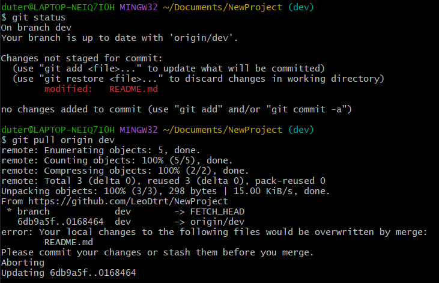

Pour se sortir de cette situation, il y a trois stratégies différentes :

1. Add et faire un commit, puis il faut gérer le conflit en local. Cette résolution du conflit entraîne une modification qu’il faut ensuite add, commit puis push sur Github
2. Stash ses modifications, faire un pull pour récupérer les modifications des autres puis récuperer ses modifications avec un stash apply et gérer le conflit en local
3. Supprimer ses modifications et faire un pull pour récupérer les modifications des autres

### 1.1 Ajouter ses modifications

git add .  
git commit -m “Nouvelle modification”  
git pull origin dev

# Ajouter ses modifications  
# Commit ses modifications  
# Récupération des modifications des autres  
# Puis gérer les conflits en local

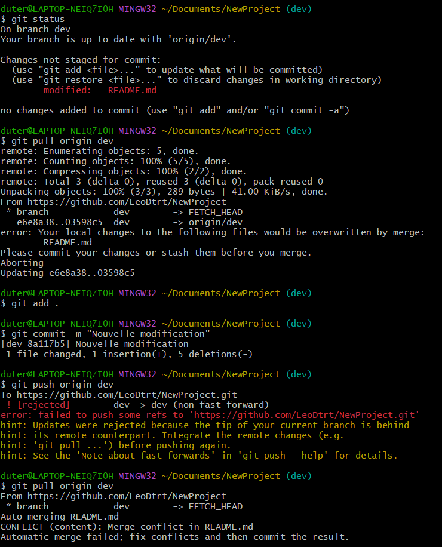

Il faut ensuite résoudre le problème en local. Autrement dit, il faut ouvrir le ou les fichiers contenant des lignes en conflit. Puis, pour chaque conflit, il faut choisir sa modification, la modification des autres ou bien une association des deux modifications.

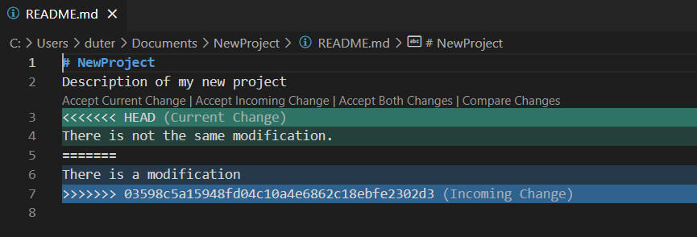

Après avoir réglé les conflits, il faut ensuite ajouter les modifications :

git add .  
git commit -m “Résolution conflit”  
git push origin dev

# Ajouter ses modifications  
# Commit de la résolution du conflit  
# Pousser le commit sur Github

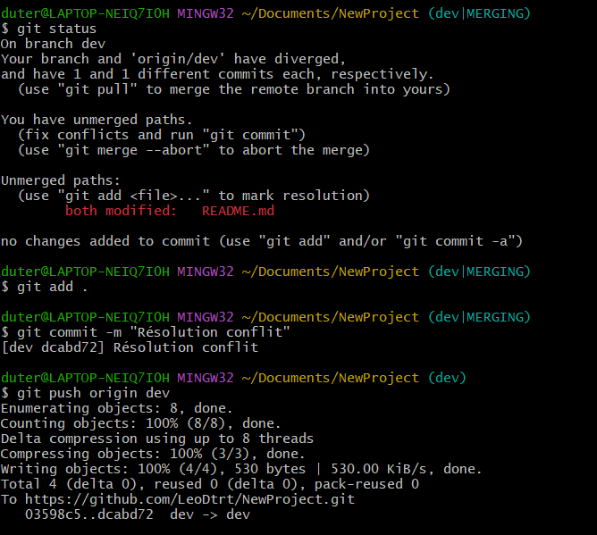

### 1.2 Couper/Coller ses modifications

git stash  
git pull origin dev  
git stash apply

# Couper ses modifications  
# Récupérer les modifications des autres  
# Coller ses modifications  
# Puis résoudre les conflits en local

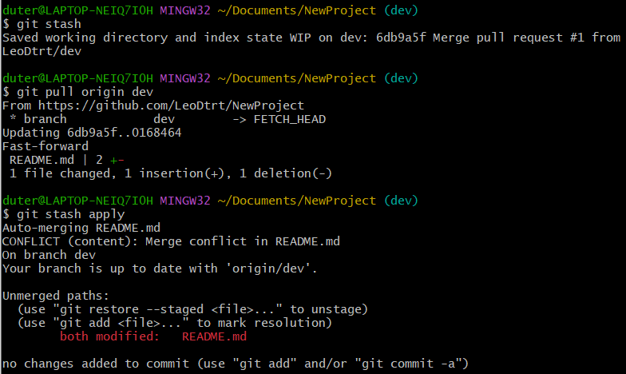

Il faut ensuite résoudre le problème en local. Autrement dit, il faut ouvrir le ou les fichiers contenant des lignes en conflit. Puis, pour chaque conflit, il faut choisir sa modification, la modification des autres ou bien une association des deux modifications.

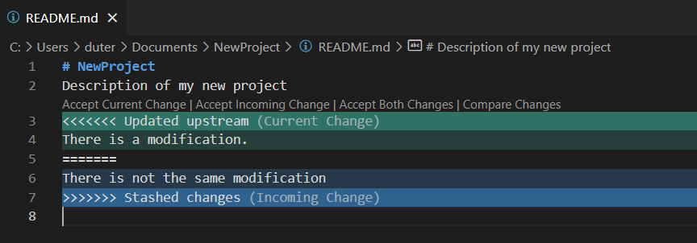

### 1.3 Supprimer ses modifications

git checkout README.md  
git checkout .  
git status  
git pull origin dev

# Supprimer la modification du README.md  
# Supprimer toutes les modifications  
# Vérifier que les modifications sont supprimées  
# Récupérer les modifications des autres

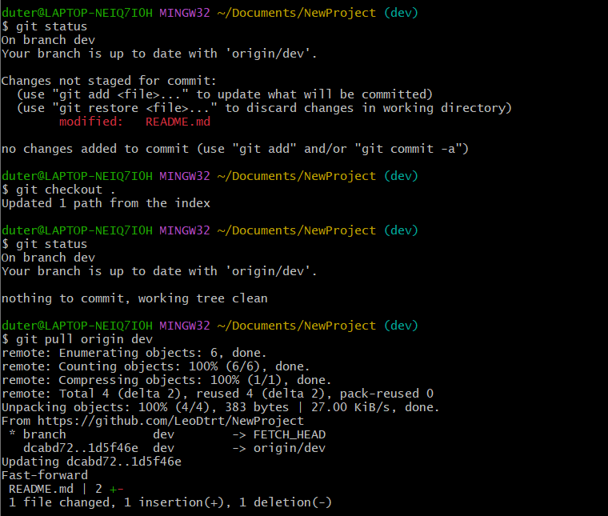

## 2. L’erreur du merge

Lorsqu’on cherche à fusionner (*merge*) une branche à une autre branche, il peut arriver d’avoir un conflit concernant une ou plusieurs modifications.

Pour résoudre ce conflit, il faut déjà le constater lors de la tentative de *merge*.

git status  
git add .  
git commit -m “Nouvelle Modification”  
git checkout main  
git merge main dev

# Constater la modification  
# Ajouter la modification  
# Commit la modification  
# Se placer sur la branche main  
# Fusionner la branche dev à la branche main  
# Constater le conflit, puis le résoudre en local

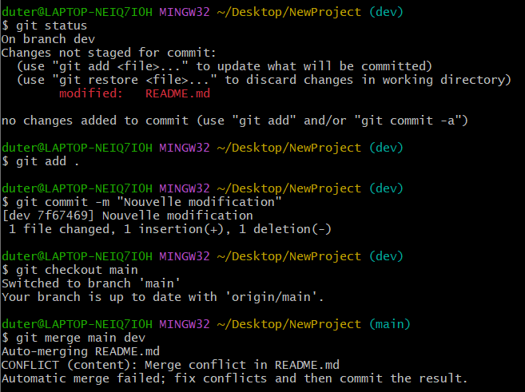

Ensuite, il faut résoudre le(s) conflit(s) en local. En d’autres termes, il faut choisir ses modifications, la modifications des autres ou alors un mélange des deux modifications.

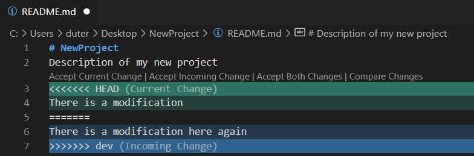

## 3. L’erreur de branche

Il peut arriver de développer sur une branche qui n’est pas celle que vous vouliez modifier à la base. Par exemple, vous êtes placé sur la branche *main* et vous effectuez des modifications alors que vous pensiez être sur la branche *dev*.

La stratégie la plus simple pour sortir de cette situation est la suivante :

git status  
git stash  
git checkout dev  
git stash apply

# Vérifier les modifications réalisées sur la mauvaise branche  
# Couper toutes les modifications réalisées  
# Se placer sur la branche dev  
# Coller toutes les modifications réalisées sur la branche dev

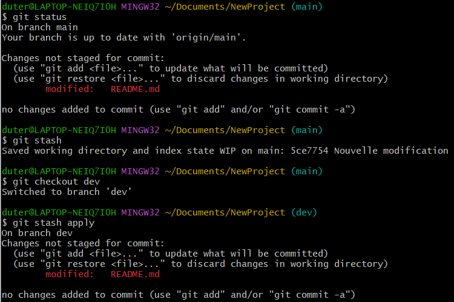